# blog_pred

Carine Hajjar

10/28/2020

# Assignment

You should report your prediction for the national result (total Electoral College votes and, if you generated it, the national popular vote) and state-level winners and include a description of how you arrived at your prediction.

Your entry should also include the following elements (not necessarily in this order): (1) model formula (or procedure for obtaining prediction), (2) model description and justification, (3) coefficients (if using regression) and/or weights (if using ensemble), (4) interpretation of coefficients and/or justification of weights, (5) model validation (recommended to include both in-sample and out-of-sample performance unless it is impossible due to the characteristics of model and related data availability), (6) uncertainty around prediction (e.g. predictive interval) (7) graphic(s) showing your prediction

# MY MODELS

## Models for my weighted ensemble:

- polls
- economy/incumbency
- demographic: already done

## POLLS

```r
dat <- state_pv_df %>%
  filter(state != "District of Columbia") %>%
  full_join(poll_state_df %>%
              filter(weeks_left <= 10) %>%
              group_by(year,party,state) %>%
              summarise(avg_poll=mean(avg_poll)),
            by = c("year" ,"state")) %>%
   filter(state != "District of Columbia",
         state != "ME-1",
         state != "ME-2",
         state != "NE-1",
         state != "NE-2",
         state != "NE-3",
         state != "National",
         party == "democrat")
# MODEL
fit_state_poll <- lm(D_pv2p ~ avg_poll + as.factor(state), data = dat)
summary(fit_state_poll)
```

```
##
## Call:
## lm(formula = D_pv2p ~ avg_poll + as.factor(state), data = dat)
##
## Residuals:
##     Min      1Q  Median      3Q     Max
## -9.5120 -2.5594 -0.3622  2.2184 11.7276
##
## Coefficients:
##                                Estimate Std. Error t value Pr(>|t|)
## (Intercept)                    13.88210    1.62726   8.531 2.26e-16 ***
## avg_poll                        0.74106    0.02719  27.259  < 2e-16 ***
## as.factor(state)Alaska         -0.95156    1.91938  -0.496 0.620303
## as.factor(state)Arizona         3.08580    1.79396   1.720 0.086104 .
## as.factor(state)Arkansas        1.18755    1.79864   0.660 0.509433
## as.factor(state)California      5.38903    1.69377   3.182 0.001566 **
## as.factor(state)Colorado        3.10413    1.71242   1.813 0.070545 .
## as.factor(state)Connecticut     6.23893    1.68513   3.702 0.000240 ***
## as.factor(state)Delaware        8.14918    1.80132   4.524 7.78e-06 ***
## as.factor(state)Florida         1.39353    1.75309   0.795 0.427095
## as.factor(state)Georgia         2.84805    1.75644   1.621 0.105617
## as.factor(state)Hawaii         10.83520    1.82390   5.941 5.70e-09 ***
## as.factor(state)Idaho          -1.09614    1.80934  -0.606 0.544938
## as.factor(state)Illinois        5.34164    1.69313   3.155 0.001714 **
## as.factor(state)Indiana         1.36953    1.84994   0.740 0.459499
## as.factor(state)Iowa            4.12228    1.71931   2.398 0.016910 *
## as.factor(state)Kansas          0.28481    1.74997   0.163 0.870788
## as.factor(state)Kentucky       -0.65350    1.74880  -0.374 0.708816
## as.factor(state)Louisiana       3.38059    1.79413   1.884 0.060178 .
## as.factor(state)Maine           7.13893    1.75744   4.062 5.74e-05 ***
## as.factor(state)Maryland        7.61410    1.73144   4.398 1.37e-05 ***
## as.factor(state)Massachusetts   9.37534    1.70600   5.496 6.55e-08 ***
## as.factor(state)Michigan        5.62308    1.71608   3.277 0.001132 **
## as.factor(state)Minnesota       5.79974    1.69178   3.428 0.000664 ***
## as.factor(state)Mississippi     1.28284    1.84925   0.694 0.488223
## as.factor(state)Missouri        3.21574    1.67989   1.914 0.056224 .
## as.factor(state)Montana         2.59623    1.84917   1.404 0.161012
## as.factor(state)Nebraska       -1.40831    1.75235  -0.804 0.422013
## as.factor(state)Nevada          4.19062    1.79527   2.334 0.020024 *
## as.factor(state)New Hampshire   2.89702    1.79898   1.610 0.108022
```

[output cut: 12 more lines]

```
## as.factor(state)Tennessee      -0.41926    1.79916  -0.233 0.815843
## as.factor(state)Texas           1.21327    1.74855   0.694 0.488122
## as.factor(state)Utah           -2.67755    1.76715  -1.515 0.130433
## as.factor(state)Vermont        10.31667    1.94144   5.314 1.69e-07 ***
## as.factor(state)Virginia        2.83583    1.75026   1.620 0.105887
## as.factor(state)Washington      6.71293    1.71833   3.907 0.000108 ***
## as.factor(state)West Virginia   1.78903    1.75173   1.021 0.307666
## as.factor(state)Wisconsin       4.85223    1.75759   2.761 0.006004 **
## as.factor(state)Wyoming        -0.51943    2.01572  -0.258 0.796764
## ---
## Signif. codes:  0 '***' 0.001 '**' 0.01 '*' 0.05 '.' 0.1 ' ' 1
##
## Residual standard error: 3.806 on 448 degrees of freedom
## Multiple R-squared:  0.837,  Adjusted R-squared:  0.8188
## F-statistic: 46.02 on 50 and 448 DF,  p-value: < 2.2e-16
```

```r
export_summs(fit_state_poll)
```

|  | Model 1 |
| --- | --- |
| (Intercept) | 13.88 *** |
|  | (1.63) |
| avg_poll | 0.74 *** |
|  | (0.03) |
| as.factor(state)Alaska | -0.95 |
|  | (1.92) |
| as.factor(state)Arizona | 3.09 |
|  | (1.79) |
| as.factor(state)Arkansas | 1.19 |
|  | (1.80) |
| as.factor(state)California | 5.39 ** |
|  | (1.69) |
| as.factor(state)Colorado | 3.10 |
|  | (1.71) |
| as.factor(state)Connecticut | 6.24 *** |
|  | (1.69) |
| as.factor(state)Delaware | 8.15 *** |
|  | (1.80) |
| as.factor(state)Florida | 1.39 |
|  | (1.75) |
| as.factor(state)Georgia | 2.85 |
|  | (1.76) |
| as.factor(state)Hawaii | 10.84 *** |
|  | (1.82) |
| as.factor(state)Idaho | -1.10 |
|  | (1.81) |
| as.factor(state)Illinois | 5.34 ** |
|  | (1.69) |
| as.factor(state)Indiana | 1.37 |
|  | (1.85) |

[output cut: 75 more lines]

```r
## prediction : take the average for each state
    # average of three weeks ago: October 8
new_data_poll <- poll_2020_state %>%
  filter(candidate_name %in% c("Joseph R. Biden Jr.",  "Convention Bounce for Joseph R. Biden Jr.")) %>%
  filter(state != "District of Columbia",
         state != "ME-1",
         state != "ME-2",
         state != "NE-1",
         state != "NE-2",
         state != "National") %>%
  mutate(date = as.Date(modeldate, format = "%m/%d/%Y")) %>%
  filter(date >= as.Date("2020-10-08")) %>%
  rename(year = cycle) %>%
  group_by(state) %>%
  summarize(avg_poll = mean(pct_estimate))  ## average poll since 10/8 per state for joe biden
```

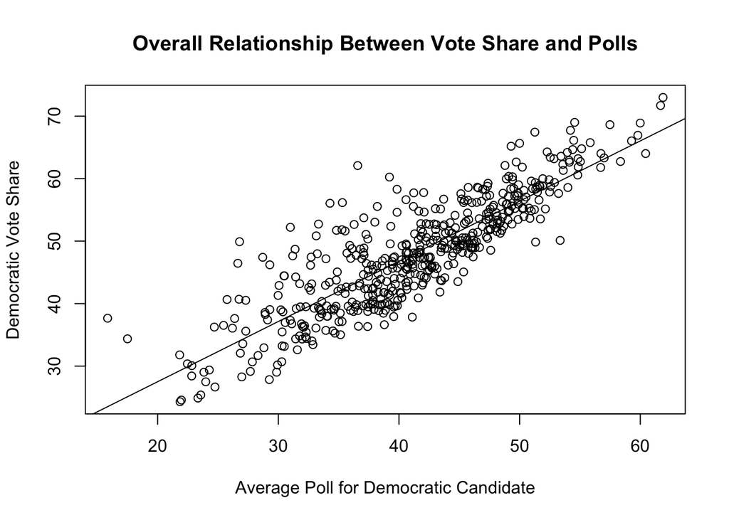

```r
plot(dat$avg_poll, dat$D_pv2p,
         main="Overall Relationship Between Vote Share and Polls", xlab="Average Poll for Democratic Candidate", ylab="Democratic Vote Share")
    abline(lm(dat$D_pv2p ~ dat$avg_poll, data = dat))
```

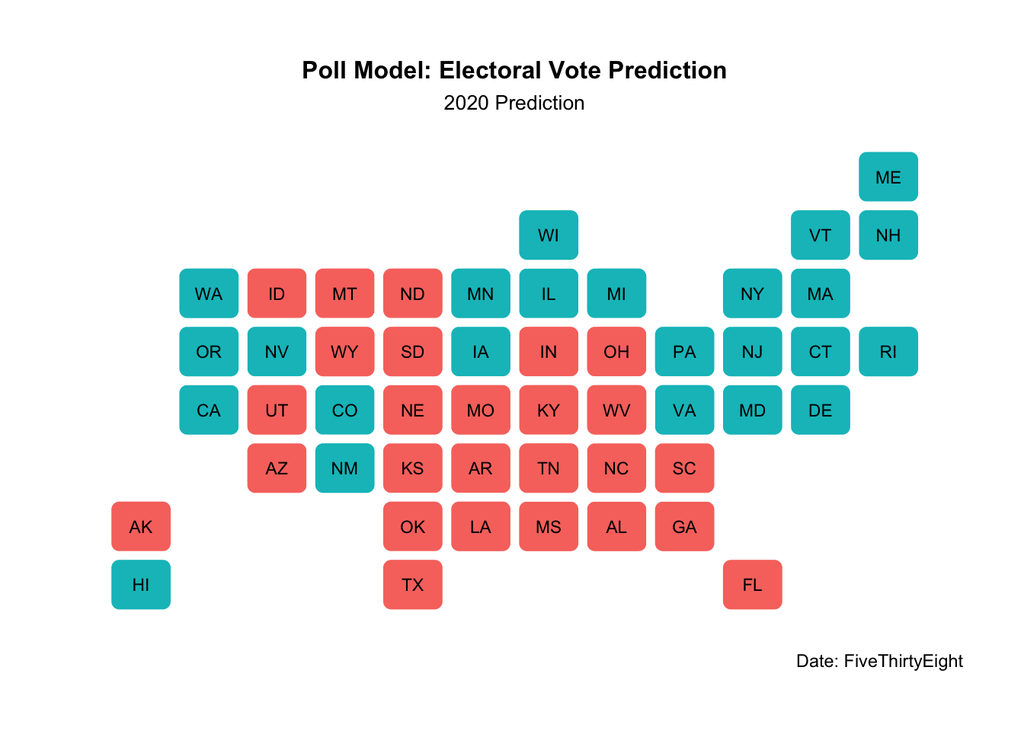

```r
# 2020 PREDICTION
pred_2020 <- predict(fit_state_poll, newdata = new_data_poll)
poll_pred_2020 <- tibble(state = new_data_poll$state, pred = pred_2020)

poll_pred_2020 %>%  ##`statebins` needs state to be character, not factor!
  ggplot(aes(state = state, fill = (pred >= 50))) +
  geom_statebins() +
  theme_statebins() +
  labs(title = "Poll Model: Electoral Vote Prediction",
       subtitle = "2020 Prediction",
       fill = "",
       caption = "Date: FiveThirtyEight") +
  theme(legend.position = "none",
        plot.subtitle = element_text(size = 10, hjust = 0.5),
        plot.title   = element_text(size = 12, hjust = 0.5, face = "bold"))
```

```r
poll_pred_2020  %>%
  select(state, pred) %>%
  mutate(state =  state.abb[match(state,state.name)]) %>%
  left_join(electoral, by = "state") %>%
  mutate(state_win = case_when(pred > 50 ~ "Biden",
                            pred < 50 ~ "Trump")) %>%
  group_by(state_win) %>%
  summarise(electoral_votes = sum(`2020`)) %>%
  gt() %>%
  tab_header(title = md("**2020 Electoral Vote Outcome Using Poll Model**"),
               subtitle = "Biden Wins") %>%
   cols_label(state_win = md("**Candidate**"),
               electoral_votes = md("**Total Electoral Votes**")) %>%
  tab_source_note(md("*Data: FiveThirtyEight*"))
```

**2020 Electoral Vote Outcome Using Poll Model**

Biden Wins

| **Candidate** | **Total Electoral Votes** |
| --- | --- |
| Biden | 282 |
| Trump | 253 |

*Data: FiveThirtyEight*

# DEMOGRAPHICS

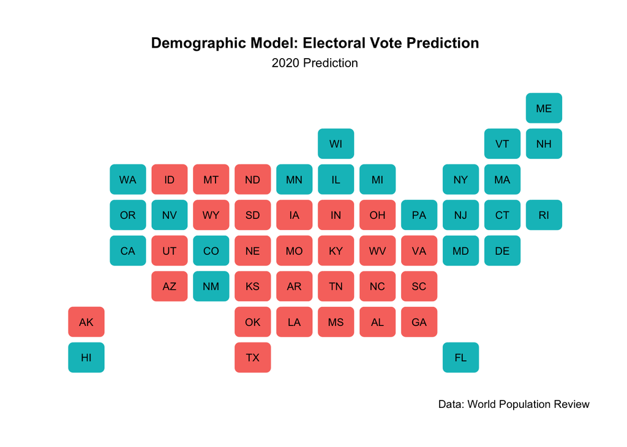

```r
demog <- read_csv("~/Desktop/R studio/carine-h.github.io/data/demographic_1990-2018.csv")
pvstate_df    <- read_csv("~/Desktop/R studio/carine-h.github.io/data/popvote_bystate_1948-2016.csv")
pollstate_df  <- read_csv("~/Desktop/R studio/carine-h.github.io/data/pollavg_bystate_1968-2016.csv")
hispanic_2020 <- read_csv("~/Desktop/R studio/carine-h.github.io/data/csvData.csv")
race_2020 <- read_csv("~/Desktop/R studio/carine-h.github.io/data/demog_race.csv")
electoral_votes <- read_csv("~/Desktop/R studio/carine-h.github.io/data/electoralcollegevotes_1948-2020.csv")
# state names and abbreviations
pvstate_df$state <- state.abb[match(pvstate_df$state, state.name)]
pollstate_df$state <- state.abb[match(pollstate_df$state, state.name)]

dat <- pvstate_df %>%
  full_join(pollstate_df %>%
              filter(weeks_left == 10) %>%
              group_by(year,party,state) %>%
              summarise(avg_poll=mean(avg_poll)),
            by = c("year" ,"state")) %>%
  left_join(demog %>%
              select(-c("total")),
            by = c("year" ,"state"))
# demographics, poll numbers, and popular vote

dat$region <- state.division[match(dat$state, state.abb)]
demog$region <- state.division[match(demog$state, state.abb)]

dat_change <- dat %>%
  group_by(state) %>%
  mutate(Asian_change = Asian - lag(Asian, order_by = year),
         Black_change = Black - lag(Black, order_by = year),
         Hispanic_change = Hispanic - lag(Hispanic, order_by = year),
         Indigenous_change = Indigenous - lag(Indigenous, order_by = year),
         White_change = White - lag(White, order_by = year),
         Female_change = Female - lag(Female, order_by = year),
         Male_change = Male - lag(Male, order_by = year),
         age20_change = age20 - lag(age20, order_by = year),
         age3045_change = age3045 - lag(age3045, order_by = year),
         age4565_change = age4565 - lag(age4565, order_by = year),
         age65_change = age65 - lag(age65, order_by = year)
  )



## MODEL
mod_demog_change <- lm(D_pv2p ~ Black_change + Hispanic_change + Asian_change +
                         as.factor(state), data = dat_change)



# UPDATED 2020
dat_2020 <- race_2020 %>%
  left_join(hispanic_2020, by = "State") %>%
  mutate(Hispanic = 100*HispanicPerc,
         state = State,
         White = 100*WhitePerc,
         Asian = 100*AsianPerc,
         Black = 100*BlackPerc) %>%
  select(state, Hispanic, White, Asian, Black) %>%
  mutate(state = state.abb[match(state,state.name)]) %>%
  na.omit() %>%
  mutate(year = 2020)

# 2018 demographics
dat_2018 <- demog %>%
  filter(year == 2018)

# joining demographics
real_2020_change <- bind_rows(dat_2018, dat_2020)

# calculating percent changes in available demographic groups
## I used 0 percent change with populations that lacked demographic data (age and gender)
real_2020 <- real_2020_change %>%
  filter(year %in% c(2018, 2020)) %>%
  group_by(state) %>%
  mutate(Asian_change = Asian - lag(Asian, order_by = year), # CALCULATING CHANGES IN POPULATION
         Black_change = Black - lag(Black, order_by = year),
         Hispanic_change = Hispanic - lag(Hispanic, order_by = year),
         Indigenous_change = 0,
         White_change = White - lag(White, order_by = year),
         Female_change = 0,
         Male_change = 0,
         age20_change = 0,
         age3045_change = 0,
         age4565_change = 0,
         age65_change = 0) %>%
  filter(year == 2020)

real_2020 <- as.data.frame(real_2020)
rownames(real_2020) <- real_2020$state
real_2020 <- real_2020[state.abb, ]
real_2020$region <- state.division[match(real_2020$state, state.abb)]

#  2020 PREDICTION
demog_pred <- predict(mod_demog_change, newdata = real_2020)

d <- tibble(demog_pred) %>%
  mutate(state = real_2020$state)


 d%>%  ##`statebins` needs state to be character, not factor!
  ggplot(aes(state = state, fill = (demog_pred >= 50))) +
  geom_statebins() +
  theme_statebins() +
  labs(title = "Demographic Model: Electoral Vote Prediction",
       subtitle = "2020 Prediction",
       fill = "",
       caption = "Data: World Population Review") +
  theme(legend.position = "none",
        plot.subtitle = element_text(size = 10, hjust = 0.5),
        plot.title   = element_text(size = 12, hjust = 0.5, face = "bold"))
```

```r
d %>%
  select(state, demog_pred) %>%
  left_join(electoral, by = "state") %>%
  mutate(state_win = case_when(demog_pred > 50 ~ "Biden",
                            demog_pred < 50 ~ "Trump")) %>%
  group_by(state_win) %>%
  summarise(electoral_votes = sum(`2020`)) %>%
  gt() %>%
  tab_header(title = md("**2020 Electoral Vote Outcome Using Demographic Model**"),
               subtitle = "Biden Wins") %>%
   cols_label(state_win = md("**Candidate**"),
               electoral_votes = md("**Total Electoral Votes**")) %>%
  tab_source_note(md("*Data: World Population Review*"))
```

**2020 Electoral Vote Outcome Using Demographic Model**

Biden Wins

| **Candidate** | **Total Electoral Votes** |
| --- | --- |
| Biden | 292 |
| Trump | 243 |

*Data: World Population Review*

# ECONOMICS

```r
library(readxl)
q2_2020 <- read_excel("pred_data/q2_2020.xlsx") %>%
  na.omit()%>%
  mutate(state = state.abb[match(state,state.name)])
state_gdp <- read_csv("pred_data/state_gdp_quarter.csv")
econ_update
```

```
## # A tibble: 484 x 31
##    GeoFIPS GeoName Region TableName LineCode IndustryClassif… Description Unit
##    <chr>   <chr>    <dbl> <chr>        <dbl> <chr>            <chr>       <chr>
##  1 00000   United…     NA SAGDP1           1 ...              Real GDP (… Mill…
##  2 00000   United…     NA SAGDP1           2 ...              Chain-type… Quan…
##  3 00000   United…     NA SAGDP1           3 ...              Current-do… Mill…
##  4 00000   United…     NA SAGDP1           4 ...              Compensati… Mill…
##  5 00000   United…     NA SAGDP1           5 ...              Gross oper… Mill…
##  6 00000   United…     NA SAGDP1           6 ...              Taxes on p… Mill…
##  7 00000   United…     NA SAGDP1           7 ...              Taxes on p… Mill…
##  8 00000   United…     NA SAGDP1           8 ...              Subsidies … Mill…
##  9 01000   Alabama      5 SAGDP1           1 ...              Real GDP (… Mill…
## 10 01000   Alabama      5 SAGDP1           2 ...              Chain-type… Quan…
## # … with 474 more rows, and 23 more variables: `1997` <dbl>, `1998` <dbl>,
## #   `1999` <dbl>, `2000` <dbl>, `2001` <dbl>, `2002` <dbl>, `2003` <dbl>,
## #   `2004` <dbl>, `2005` <dbl>, `2006` <dbl>, `2007` <dbl>, `2008` <dbl>,
## #   `2009` <dbl>, `2010` <dbl>, `2011` <dbl>, `2012` <dbl>, `2013` <dbl>,
## #   `2014` <dbl>, `2015` <dbl>, `2016` <dbl>, `2017` <dbl>, `2018` <dbl>,
## #   `2019` <dbl>
```

```r
# going to have to use yearly growth
state_econ <- econ_update %>%
  filter(Description == "Real GDP (millions of chained 2012 dollars)") %>%
  select(GeoName, '1997', '1998', '1999','2000', '2001', '2002', '2003', '2004', '2005', '2006', '2007', '2008', '2009', '2010', '2011', '2012', '2013', '2014', '2015', '2016', '2017', '2018')%>%
  melt(c("GeoName"), value.name = "GDP") %>%
  mutate(year = as.numeric(as.character(variable))) %>%
  rename(state = GeoName) %>%
  group_by(state) %>%
  mutate(gdp_growth= (GDP - lag(GDP, order_by = year))/lag(GDP, order_by = year)) %>%
  mutate(state = state.abb[match(state,state.name)]) %>%
  select(year, state, gdp_growth) %>%
  na.omit()



q3_econ <- pvstate_df %>%
  left_join(state_econ, by = c("year", "state")) %>%
  left_join(popvote_df, by = c("year")) %>%
  na.omit() %>%
  filter(party == "democrat")

# MODEL
econ_fit <- lm(D_pv2p ~ gdp_growth*incumbent + as.factor(state), data = q3_econ)
summary(econ_fit)
```

```
##
## Call:
## lm(formula = D_pv2p ~ gdp_growth * incumbent + as.factor(state),
##     data = q3_econ)
##
## Residuals:
##      Min       1Q   Median       3Q      Max
## -12.1919  -1.9037   0.0077   1.9924  10.7792
##
## Coefficients:
##                          Estimate Std. Error t value Pr(>|t|)
## (Intercept)               38.1650     1.5989  23.870  < 2e-16 ***
## gdp_growth               -29.9112     9.3138  -3.211 0.001542 **
## incumbentTRUE              0.3537     0.6640   0.533 0.594849
## as.factor(state)AL         0.8672     2.2617   0.383 0.701828
## as.factor(state)AR         3.2325     2.2585   1.431 0.153933
## as.factor(state)AZ         8.4376     2.2607   3.732 0.000248 ***
## as.factor(state)CA        22.9524     2.2720  10.102  < 2e-16 ***
## as.factor(state)CO        13.0791     2.2651   5.774 2.97e-08 ***
## as.factor(state)CT        20.8874     2.2696   9.203  < 2e-16 ***
## as.factor(state)DE        19.4663     2.2588   8.618 2.21e-15 ***
## as.factor(state)FL        12.0844     2.2634   5.339 2.56e-07 ***
## as.factor(state)GA         7.5603     2.2606   3.344 0.000987 ***
## as.factor(state)HI        27.7259     2.2649  12.242  < 2e-16 ***
## as.factor(state)IA        12.8317     2.2594   5.679 4.80e-08 ***
## as.factor(state)ID        -4.4666     2.2993  -1.943 0.053488 .
## as.factor(state)IL        20.3558     2.2539   9.031  < 2e-16 ***
## as.factor(state)IN         5.6256     2.2621   2.487 0.013716 *
## as.factor(state)KS         1.5380     2.2600   0.681 0.496974
## as.factor(state)KY         1.1419     2.2530   0.507 0.612824
## as.factor(state)LA         3.8342     2.2568   1.699 0.090905 .
## as.factor(state)MA        25.9295     2.2663  11.441  < 2e-16 ***
## as.factor(state)MD        23.6211     2.2718  10.397  < 2e-16 ***
## as.factor(state)ME        17.5037     2.2669   7.722 5.67e-13 ***
## as.factor(state)MI        15.1378     2.2516   6.723 1.88e-10 ***
## as.factor(state)MN        15.1504     2.2688   6.678 2.42e-10 ***
## as.factor(state)MO         8.1954     2.2591   3.628 0.000364 ***
## as.factor(state)MS         4.2262     2.2585   1.871 0.062793 .
## as.factor(state)MT         3.3494     2.2556   1.485 0.139161
## as.factor(state)NC         9.3230     2.2665   4.113 5.73e-05 ***
```

[output cut: 15 more lines]

```
## as.factor(state)TX         4.0057     2.2568   1.775 0.077453 .
## as.factor(state)UT        -6.8451     2.2667  -3.020 0.002864 **
## as.factor(state)VA        12.3160     2.2645   5.439 1.58e-07 ***
## as.factor(state)VT        26.1969     2.2717  11.532  < 2e-16 ***
## as.factor(state)WA        18.5109     2.2554   8.207 2.91e-14 ***
## as.factor(state)WI        14.1764     2.2562   6.283 2.08e-09 ***
## as.factor(state)WV         1.4166     2.2573   0.628 0.531019
## as.factor(state)WY        -8.6865     2.2701  -3.826 0.000175 ***
## gdp_growth:incumbentTRUE  40.8028    19.5016   2.092 0.037694 *
## ---
## Signif. codes:  0 '***' 0.001 '**' 0.01 '*' 0.05 '.' 0.1 ' ' 1
##
## Residual standard error: 3.555 on 197 degrees of freedom
## Multiple R-squared:  0.8985, Adjusted R-squared:  0.8717
## F-statistic: 33.55 on 52 and 197 DF,  p-value: < 2.2e-16
```

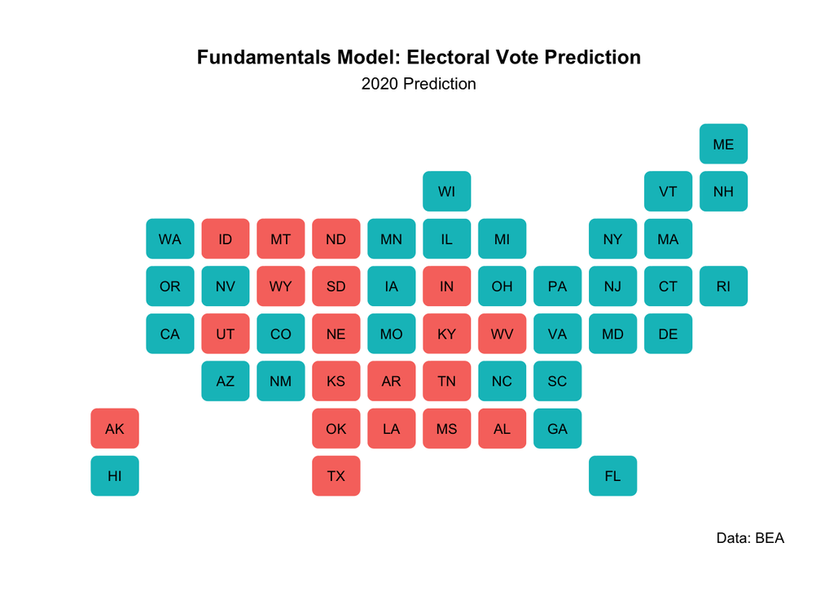

```r
e <- econ_update %>%
  filter(Description == "Real GDP (millions of chained 2012 dollars)") %>%
  select(GeoName, '1997', '1998', '1999','2000', '2001', '2002', '2003', '2004', '2005', '2006', '2007', '2008', '2009', '2010', '2011', '2012', '2013', '2014', '2015', '2016', '2017', '2018')%>%
  melt(c("GeoName"), value.name = "GDP") %>%
  mutate(year = as.numeric(as.character(variable))) %>%
  rename(state = GeoName) %>%
  mutate(state = state.abb[match(state,state.name)]) %>%
  select(state, year, GDP) %>%
  filter(year == 2018)


gdp_2019 <- read_excel("pred_data/state_2019_gdp.xlsx")%>%
  na.omit()%>%
  mutate(state = state.abb[match(state,state.name)]) %>%
  mutate(year = 2019)

# new data: ASSUMING SAME GDP GROWTH ACROSS STATES AS IS NATIONALLY
data_econ <- q2_2020 %>%
  mutate(year = 2020)

new_data_econ <- rbind(data_econ, gdp_2019) %>%
  mutate(incumbent = FALSE) %>%
  group_by(state) %>%
  mutate(gdp_growth = (GDP - lag(GDP, order_by = year))/lag(GDP, order_by = year)) %>%
  na.omit()


# 2020 PREDICTION
econ_pred <- predict(econ_fit, newdata = new_data_econ)

e2 <- tibble(pred = predict(econ_fit, newdata = new_data_econ), state = new_data_econ$state)

e2 %>%  ##`statebins` needs state to be character, not factor!
  ggplot(aes(state = state, fill = (pred >= 50))) +
  geom_statebins() +
  theme_statebins() +
  labs(title = "Fundamentals Model: Electoral Vote Prediction",
       subtitle = "2020 Prediction",
       fill = "",
       caption = "Data: BEA") +
  theme(legend.position = "none",
        plot.subtitle = element_text(size = 10, hjust = 0.5),
        plot.title   = element_text(size = 12, hjust = 0.5, face = "bold"))
```

```r
e2  %>%
  select(state, pred) %>%
  left_join(electoral, by = "state") %>%
  mutate(state_win = case_when(pred > 50 ~ "Biden",
                            pred < 50 ~ "Trump")) %>%
  group_by(state_win) %>%
  summarise(electoral_votes = sum(`2020`)) %>%
  gt() %>%
  tab_header(title = md("**2020 Electoral Vote Outcome Using Fundamentals Model**"),
               subtitle = "Biden Wins") %>%
   cols_label(state_win = md("**Candidate**"),
               electoral_votes = md("**Total Electoral Votes**")) %>%
  tab_source_note(md("*Data: FiveThirtyEight, BEA*"))
```

**2020 Electoral Vote Outcome Using Fundamentals Model**

Biden Wins

| **Candidate** | **Total Electoral Votes** |
| --- | --- |
| Biden | 390 |
| Trump | 145 |

*Data: FiveThirtyEight, BEA*